# Telecom: Identificación de operadores ineficaces

> **Vista ejecutiva (HTML):** narrativa, tablas y figuras sin código. La versión técnica completa se entrega aparte.

## TL;DR (30 segundos)

- **Problema:** pérdidas elevadas en entrantes y esperas largas; necesitamos identificar **operadores menos eficaces** por cliente.
- **Qué hicimos:** EDA, métricas por **día–operador**, reglas por **cliente** (percentiles), pruebas estadísticas (Mann-Whitney, Kruskal, Spearman) y un **dashboard** en Tableau.
- **Qué sigue:** coaching a operadores marcados, ajustes de enrutamiento/turnos y adopción del dashboard con alertas.

## 1. Datos y supuestos

- Fuentes: `telecom_dataset_us.csv`, `telecom_clients_us.csv`.
- Unión: `user_id`. Grano: **día–operador**.
- Definiciones: `wait_time = total_call_duration - call_duration` (>= 0), entrante asignada = contestada + perdida **post**.
- Ventana de análisis: últimas **4 semanas** (o todo el periodo si menor).

## 2. Construcción de métricas

Resumen de cómo se generan las métricas diarias por operador (entrantes, perdidas post, espera, OUT) y su agregación por cliente/operador.

## 4. Reglas para operadores ineficaces

Se marca **ineficaz** si, con volumen suficiente, cumple:

- `missed_rate_post` ≥ P80 **y** `avg_wait_in_ans` ≥ P80; **o**
- `missed_rate_post` ≥ P80 **y** OUT bajo (≤ P20) cuando `expected_outbound`. Umbrales por **cliente** para ser justos con el contexto.

## 5. Hipótesis y resultados

- **H1:** Internas vs Externas (espera) — *rechazamos H0*. Cliff’s δ ≈ −0.185 (pequeño).
- **H2:** Plan tarifario — *no diferencias*. ε² ≈ 0.
- **H3:** Abandono pre vs pérdidas post — ρ ≈ −0.169 (negativa pequeña).

## 6. Exports (archivos para supervisión)

- `s14_operadores_ineficaces_metrics.csv` — tabla por operador con banderas y etiqueta final.
- `s14_queue_context_por_cliente.csv` — contexto de cola (pre-asignación) por cliente.
- `s14_daily_base_operador.csv` — trazabilidad día–operador.

## 7. Recomendaciones

- Quick wins (coaching a marcados, ajustes de routing en picos).
- Corto plazo (rebalanceo de turnos, QA scriptado).
- Estructural (KPI y alertas en Tableau; playbook de supervisión).

Portada - S14

```
669892
```

```
Ventana de tiempo para análisis: Del  2019-11-01 hasta el 2019-11-28 00:00:00+03:00
```

```
     user_id  operator_id  in_ans_calls  in_miss_post_calls  in_ans_wait_sum  \
0     166377     880022.0             7                   0               94
1     166377     880026.0             5                   0               42
2     166377     880028.0            29                   0              172
3     166377     881278.0             0                   0                0
4     166391     882476.0             1                   0               64
..       ...          ...           ...                 ...              ...
777   168598     958394.0            23                   0              171
778   168601     952914.0            98                   0              729
779   168601     952916.0             1                   0               25
780   168603     959118.0             0                   0                0
781   168606     957922.0             2                   1               19

     in_miss_post_wait_sum  out_ext_calls  avg_wait_in_ans  missed_rate_post  \
0                        0             36        13.428571          0.000000
```

[output cut: 65 more lines]

```
   user_id  pre_missed_calls  pre_avg_wait
0   166377                17     14.250000
1   166391                 2      4.000000
2   166392                31      7.022222
3   166405              1392     15.611976
4   166406                21     26.983333
```

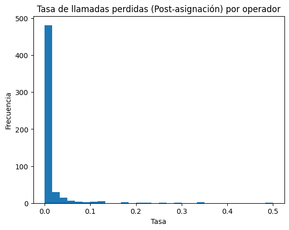

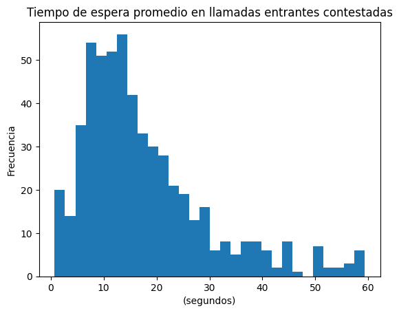

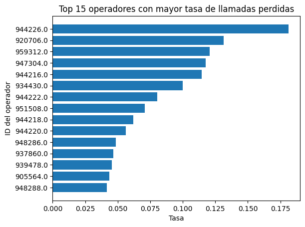

```
Mann-Whitney U p=3.408e-06
Cliff's delta=-0.185  (≈0.147 pequeño, ≈0.33 mediano, ≈0.474 grande)
```

#### Conclusión:

- Aplicamos la prueba U Mann-Whitney sobre la espera media por llamada en entrantes contestadas, comparando internas vs. externas.
- El resultado fue p = 3.408e-06, por lo que **rechazamos H0**: existe una diferencia estadísticamente significativa entre ambos tipos de llamada. El tamaño del efecto Cliff’s fue −0.185, de magnitud pequeña; el signo negativo indica que las internas tienden a menor espera que las externas.
- Implicación: La experiencia de clientes externos presenta esperas relativamente más altas; conviene revisar enrutamiento y priorización para llamadas externas.
- **En pocas palabas: Existen diferencias en la espera; externas esperan más que las internas.**

```
Kruskal-Wallis: H=1.376, p=0.5026, epsilon^2=-0.003
```

#### Conclusión:

- Se evaluó si la tasa de pérdidas post-asignación difiere entre planes tarifarios. Con H = 1.376, p = 0.5026, **no rechazamos H0**: no hay evidencia de diferencias entre planes. El epsilon-cuadrado fue ≈ −0.003 (interpretado como ≈ 0), es decir, efecto nulo.
- Implicación: la variación en la tasa de pérdidas post-asignación no se explica por el plan tarifario; habrá que enfocar acciones en factores operativos (enrutamiento, horarios, coaching a operadores) más que en la tarifa.
- **En pocas palabras: Sin diferencias por plan tarifario en pérdidas post-asignación (efecto nulo).**

```
Spearman rho=-0.169, p=0.01013
```

#### Conclusión:

Se realiza la correlación entre la tasa de abandono en espera y la tasa media de pérdidas post-asignación por cliente.

- El valor El resultado fue rho = −0.169, p = 0.01013: existe una asociación negativa significativa, pero de magnitud pequeña.
- Implicación: A nivel cliente, **un mayor abandono en cola no se asocia con mayores pérdidas post-asignación**; por lo que en términos prácticos, conviene tratar lista de espera y desempeño post-asignación como frentes operativos distintos, evitando extraer conclusiones causales sin un análisis adicional (p. ej., por franjas horarias, mezcla de tráfico, reglas de routing).
- **Correlación negativa y pequeña entre abandono en espera y pérdidas post.**

### Fuentes documentales:

1. **SciPy – `scipy.stats.mannwhitneyu`**.- Prueba no paramétrica para comparar dos muestras independientes (diferencia de localización/rangos); la utilizamos para contrastar si la espera en llamadas entrantes (internas vs externas) difiere de forma significativa.
2. **SciPy – `scipy.stats.kruskal`**.- Prueba no paramétrica utilizada para comparar **k** grupos con tamaños distintos; la utilizamos para ver si la tasa de pérdidas post-asignación cambia por plan tarifario.
3. **SciPy – `scipy.stats.spearmanr`**.- Sirve para conocer la correlación de Spearman (ρ) para relaciones monótonas sin suponer normalidad;la utilizamos para conocer la relación entre tasa de abandono en espera (pre) y pérdidas post-asignación a nivel cliente.
4. **NumPy – `numpy.nanpercentile`**.- Librería utilizada para calcular percentiles ignorando NaN; la utilizamos para definir umbrales por cliente (P80 para perdidas/en-espera, P20 para llamadas salientes) y generar métricas justas por contexto.
5. **Cliff’s delta**.- Sirve para entender y reportar el tamaño de efecto no paramétrico para comparaciones de dos grupos; la utilizamos para cuantificar la magnitud práctica al investigar si la espera en llamadas entrantes contestadas difiere entre internas vs externas.
6. **Epsilon squared**.- Se utiliza para calcular el epsilon cuadrado para Kruskal–Wallis como medida de tamaño de efecto; se utilizó para reportar la magnitud entre los grupos al investigar si el plan tarifario del cliente se asocia con la tasa de llamadas perdidas post-asignación.
7. **Genesys – Definición de ASA (Average Speed of Answer)**.- Documentación operativa de contact centers; se utilizó para definir el tiempo de espera hasta que recibe respuesta (ASA) y distinguirla de otras esperas y separar correctamente la espera pre-asignación (cola/equipo) de la espera post-asignación (operador) en nuestras métricas.
8. **Investopedia – Abandon Rate (definición y fórmula)**.- Definición de la tasa de abandono en call centers (abandoned / inbound) y su relación con tiempos de espera; se utilizó para fundamentar la métrica de abandono en espera usada como contexto de equipo (no para culpar a individuos).

## 8. Notas de auditoría y cambios

No se detectaron inconsistencias estructurales. Se añadieron portada, TL;DR, encabezados y notas.